# Risk Factor Analysis

## Outcome Variable

**Outcome Variable:** wast_rec90d

## Predictor Variables

**Intervention Variable:** gagebrth

**Adjustment Set:**

- arm
- sex
- W_mage
- meducyrs
- feducyrs
- hhwealth_quart
- brthmon
- W_parity
- delta_W_mage
- delta_meducyrs
- delta_feducyrs
- delta_hhwealth_quart
- delta_brthmon
- delta_W_parity

## Stratifying Variables

The analysis was stratified on these variable(s):

- agecat
- studyid
- country

## Data Summary

| agecat | studyid | country | gagebrth | wast_rec90d | n_cell | n |
| --- | --- | --- | --- | --- | --- | --- |
| 0-24 months | ki1000108-CMC-V-BCS-2002 | INDIA | Full or late term | 0 | 68 | 301 |
| 0-24 months | ki1000108-CMC-V-BCS-2002 | INDIA | Full or late term | 1 | 119 | 301 |
| 0-24 months | ki1000108-CMC-V-BCS-2002 | INDIA | Preterm | 0 | 21 | 301 |
| 0-24 months | ki1000108-CMC-V-BCS-2002 | INDIA | Preterm | 1 | 28 | 301 |
| 0-24 months | ki1000108-CMC-V-BCS-2002 | INDIA | Early term | 0 | 21 | 301 |
| 0-24 months | ki1000108-CMC-V-BCS-2002 | INDIA | Early term | 1 | 44 | 301 |
| 0-24 months | ki1000108-IRC | INDIA | Full or late term | 0 | 92 | 382 |
| 0-24 months | ki1000108-IRC | INDIA | Full or late term | 1 | 134 | 382 |
| 0-24 months | ki1000108-IRC | INDIA | Preterm | 0 | 24 | 382 |
| 0-24 months | ki1000108-IRC | INDIA | Preterm | 1 | 29 | 382 |
| 0-24 months | ki1000108-IRC | INDIA | Early term | 0 | 39 | 382 |
| 0-24 months | ki1000108-IRC | INDIA | Early term | 1 | 64 | 382 |
| 0-24 months | ki1000109-EE | PAKISTAN | Full or late term | 0 | 4 | 257 |
| 0-24 months | ki1000109-EE | PAKISTAN | Full or late term | 1 | 6 | 257 |
| 0-24 months | ki1000109-EE | PAKISTAN | Preterm | 0 | 98 | 257 |
| 0-24 months | ki1000109-EE | PAKISTAN | Preterm | 1 | 78 | 257 |
| 0-24 months | ki1000109-EE | PAKISTAN | Early term | 0 | 48 | 257 |
| 0-24 months | ki1000109-EE | PAKISTAN | Early term | 1 | 23 | 257 |
| 0-24 months | ki1000304b-SAS-CompFeed | INDIA | Full or late term | 0 | 9 | 810 |
| 0-24 months | ki1000304b-SAS-CompFeed | INDIA | Full or late term | 1 | 5 | 810 |
| 0-24 months | ki1000304b-SAS-CompFeed | INDIA | Preterm | 0 | 463 | 810 |
| 0-24 months | ki1000304b-SAS-CompFeed | INDIA | Preterm | 1 | 282 | 810 |
| 0-24 months | ki1000304b-SAS-CompFeed | INDIA | Early term | 0 | 29 | 810 |
| 0-24 months | ki1000304b-SAS-CompFeed | INDIA | Early term | 1 | 22 | 810 |
| 0-24 months | ki1017093c-NIH-Crypto | BANGLADESH | Full or late term | 0 | 16 | 311 |
| 0-24 months | ki1017093c-NIH-Crypto | BANGLADESH | Full or late term | 1 | 26 | 311 |
| 0-24 months | ki1017093c-NIH-Crypto | BANGLADESH | Preterm | 0 | 57 | 311 |
| 0-24 months | ki1017093c-NIH-Crypto | BANGLADESH | Preterm | 1 | 92 | 311 |
| 0-24 months | ki1017093c-NIH-Crypto | BANGLADESH | Early term | 0 | 44 | 311 |
| 0-24 months | ki1017093c-NIH-Crypto | BANGLADESH | Early term | 1 | 76 | 311 |

[output cut: 186 more lines]

The following strata were considered:

- agecat: 0-24 months, studyid: ki1000108-CMC-V-BCS-2002, country: INDIA
- agecat: 0-24 months, studyid: ki1000108-IRC, country: INDIA
- agecat: 0-24 months, studyid: ki1000109-EE, country: PAKISTAN
- agecat: 0-24 months, studyid: ki1000304b-SAS-CompFeed, country: INDIA
- agecat: 0-24 months, studyid: ki1017093c-NIH-Crypto, country: BANGLADESH
- agecat: 0-24 months, studyid: ki1066203-TanzaniaChild2, country: TANZANIA, UNITED REPUBLIC OF
- agecat: 0-24 months, studyid: ki1101329-Keneba, country: GAMBIA
- agecat: 0-24 months, studyid: ki1119695-PROBIT, country: BELARUS
- agecat: 0-24 months, studyid: ki1135781-COHORTS, country: GUATEMALA
- agecat: 0-24 months, studyid: ki1135781-COHORTS, country: INDIA
- agecat: 0-24 months, studyid: ki1135781-COHORTS, country: PHILIPPINES
- agecat: 0-24 months, studyid: kiGH5241-JiVitA-3, country: BANGLADESH
- agecat: 0-6 months, studyid: ki1000108-CMC-V-BCS-2002, country: INDIA
- agecat: 0-6 months, studyid: ki1000108-IRC, country: INDIA
- agecat: 0-6 months, studyid: ki1000109-EE, country: PAKISTAN
- agecat: 0-6 months, studyid: ki1000304b-SAS-CompFeed, country: INDIA
- agecat: 0-6 months, studyid: ki1017093c-NIH-Crypto, country: BANGLADESH
- agecat: 0-6 months, studyid: ki1066203-TanzaniaChild2, country: TANZANIA, UNITED REPUBLIC OF
- agecat: 0-6 months, studyid: ki1101329-Keneba, country: GAMBIA
- agecat: 0-6 months, studyid: ki1119695-PROBIT, country: BELARUS
- agecat: 0-6 months, studyid: ki1135781-COHORTS, country: GUATEMALA
- agecat: 0-6 months, studyid: ki1135781-COHORTS, country: INDIA
- agecat: 0-6 months, studyid: ki1135781-COHORTS, country: PHILIPPINES
- agecat: 0-6 months, studyid: kiGH5241-JiVitA-3, country: BANGLADESH
- agecat: 6-24 months, studyid: ki1000108-CMC-V-BCS-2002, country: INDIA
- agecat: 6-24 months, studyid: ki1000108-IRC, country: INDIA
- agecat: 6-24 months, studyid: ki1000109-EE, country: PAKISTAN
- agecat: 6-24 months, studyid: ki1000304b-SAS-CompFeed, country: INDIA
- agecat: 6-24 months, studyid: ki1017093c-NIH-Crypto, country: BANGLADESH
- agecat: 6-24 months, studyid: ki1066203-TanzaniaChild2, country: TANZANIA, UNITED REPUBLIC OF
- agecat: 6-24 months, studyid: ki1101329-Keneba, country: GAMBIA
- agecat: 6-24 months, studyid: ki1119695-PROBIT, country: BELARUS
- agecat: 6-24 months, studyid: ki1135781-COHORTS, country: GUATEMALA
- agecat: 6-24 months, studyid: ki1135781-COHORTS, country: INDIA
- agecat: 6-24 months, studyid: ki1135781-COHORTS, country: PHILIPPINES
- agecat: 6-24 months, studyid: kiGH5241-JiVitA-3, country: BANGLADESH

### Dropped Strata

Some strata were dropped due to rare outcomes:

- agecat: 0-24 months, studyid: ki1000109-EE, country: PAKISTAN
- agecat: 0-6 months, studyid: ki1000109-EE, country: PAKISTAN
- agecat: 0-6 months, studyid: ki1000304b-SAS-CompFeed, country: INDIA
- agecat: 0-6 months, studyid: ki1017093c-NIH-Crypto, country: BANGLADESH
- agecat: 6-24 months, studyid: ki1000109-EE, country: PAKISTAN
- agecat: 6-24 months, studyid: ki1000304b-SAS-CompFeed, country: INDIA
- agecat: 6-24 months, studyid: ki1017093c-NIH-Crypto, country: BANGLADESH
- agecat: 6-24 months, studyid: ki1119695-PROBIT, country: BELARUS
- agecat: 6-24 months, studyid: ki1135781-COHORTS, country: GUATEMALA
- agecat: 6-24 months, studyid: ki1135781-COHORTS, country: INDIA
- agecat: 6-24 months, studyid: kiGH5241-JiVitA-3, country: BANGLADESH

## Methods Detail

We’re interested in the causal parameters $E[Y_a]$ for all values of $a \in \mathcal{A}$. These parameters represent the mean outcome if, possibly contrary to fact, we intervened to set all units to have $A=a$. Under the randomization and positivity assumptions, these are identified by the statistical parameters $\psi_a=E_W[E_{Y|A,W}(Y|A=a,W)]$. In addition, we’re interested in the mean of $Y$, $E[Y]$ under no intervention (the observed mean). We will estimate these parameters by using SuperLearner to fit the relevant likelihood factors – $E_{Y|A,W}(Y|A=a,W)$ and $p(A=a|W)$, and then updating our likelihood fit using a joint TMLE.

For unadjusted analyses ($W=\{\}$), initial likelihoods were estimated using Lrnr_glm to estimate the simple $E(Y|A)$ and Lrnr_mean to estimate $p(A)$. For adjusted analyses, a small library containing Lrnr_glmnet, Lrnr_xgboost, and Lrnr_mean was used.

Having estimated these parameters, we will then use the delta method to estimate relative risks and attributable risks relative to a prespecified baseline level of $A$.

# Results Detail

## Results Plots

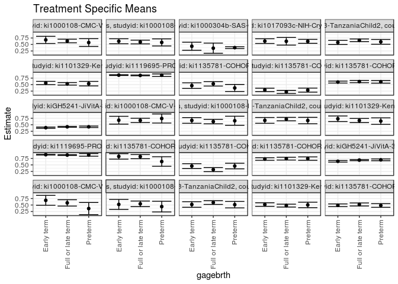

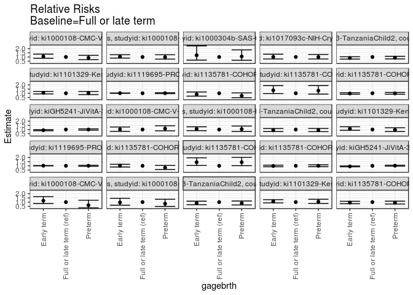

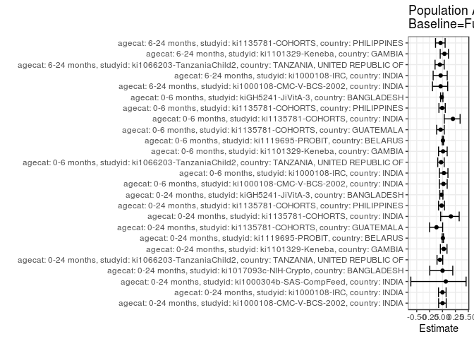

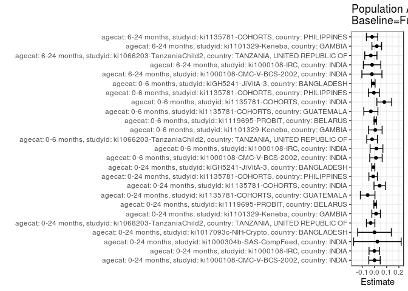

## Results Table

### Parameter: TSM

| agecat | studyid | country | intervention_level | baseline_level | estimate | ci_lower | ci_upper |
| --- | --- | --- | --- | --- | --- | --- | --- |
| 0-24 months | ki1000108-CMC-V-BCS-2002 | INDIA | Full or late term | NA | 0.6338669 | 0.5636636 | 0.7040703 |
| 0-24 months | ki1000108-CMC-V-BCS-2002 | INDIA | Preterm | NA | 0.5741955 | 0.4251542 | 0.7232369 |
| 0-24 months | ki1000108-CMC-V-BCS-2002 | INDIA | Early term | NA | 0.6762276 | 0.5386550 | 0.8138002 |
| 0-24 months | ki1000108-IRC | INDIA | Full or late term | NA | 0.5948541 | 0.5227548 | 0.6669533 |
| 0-24 months | ki1000108-IRC | INDIA | Preterm | NA | 0.5799110 | 0.4433363 | 0.7164856 |
| 0-24 months | ki1000108-IRC | INDIA | Early term | NA | 0.6248668 | 0.5294980 | 0.7202356 |
| 0-24 months | ki1000304b-SAS-CompFeed | INDIA | Full or late term | NA | 0.3571429 | 0.1608018 | 0.5534839 |
| 0-24 months | ki1000304b-SAS-CompFeed | INDIA | Preterm | NA | 0.3785235 | 0.3421693 | 0.4148777 |
| 0-24 months | ki1000304b-SAS-CompFeed | INDIA | Early term | NA | 0.4313725 | 0.2762267 | 0.5865184 |
| 0-24 months | ki1017093c-NIH-Crypto | BANGLADESH | Full or late term | NA | 0.6233690 | 0.4763559 | 0.7703821 |
| 0-24 months | ki1017093c-NIH-Crypto | BANGLADESH | Preterm | NA | 0.6208748 | 0.5436380 | 0.6981116 |
| 0-24 months | ki1017093c-NIH-Crypto | BANGLADESH | Early term | NA | 0.6293700 | 0.5380559 | 0.7206841 |
| 0-24 months | ki1066203-TanzaniaChild2 | TANZANIA, UNITED REPUBLIC OF | Full or late term | NA | 0.6601979 | 0.6090602 | 0.7113356 |
| 0-24 months | ki1066203-TanzaniaChild2 | TANZANIA, UNITED REPUBLIC OF | Preterm | NA | 0.6026870 | 0.5106581 | 0.6947160 |
| 0-24 months | ki1066203-TanzaniaChild2 | TANZANIA, UNITED REPUBLIC OF | Early term | NA | 0.5789314 | 0.4992197 | 0.6586431 |
| 0-24 months | ki1101329-Keneba | GAMBIA | Full or late term | NA | 0.5299405 | 0.4812839 | 0.5785972 |
| 0-24 months | ki1101329-Keneba | GAMBIA | Preterm | NA | 0.5371709 | 0.4502174 | 0.6241245 |
| 0-24 months | ki1101329-Keneba | GAMBIA | Early term | NA | 0.5626461 | 0.4999110 | 0.6253813 |
| 0-24 months | ki1119695-PROBIT | BELARUS | Full or late term | NA | 0.8553497 | 0.8404976 | 0.8702018 |
| 0-24 months | ki1119695-PROBIT | BELARUS | Preterm | NA | 0.8625521 | 0.8129290 | 0.9121751 |
| 0-24 months | ki1119695-PROBIT | BELARUS | Early term | NA | 0.8660596 | 0.8515208 | 0.8805984 |
| 0-24 months | ki1135781-COHORTS | GUATEMALA | Full or late term | NA | 0.5304614 | 0.4449529 | 0.6159699 |
| 0-24 months | ki1135781-COHORTS | GUATEMALA | Preterm | NA | 0.3707280 | 0.2350617 | 0.5063943 |
| 0-24 months | ki1135781-COHORTS | GUATEMALA | Early term | NA | 0.4610397 | 0.3531913 | 0.5688881 |
| 0-24 months | ki1135781-COHORTS | INDIA | Full or late term | NA | 0.2192648 | 0.1600130 | 0.2785166 |
| 0-24 months | ki1135781-COHORTS | INDIA | Preterm | NA | 0.2879734 | 0.2107054 | 0.3652413 |
| 0-24 months | ki1135781-COHORTS | INDIA | Early term | NA | 0.2965622 | 0.2310055 | 0.3621190 |
| 0-24 months | ki1135781-COHORTS | PHILIPPINES | Full or late term | NA | 0.6166273 | 0.5736210 | 0.6596336 |
| 0-24 months | ki1135781-COHORTS | PHILIPPINES | Preterm | NA | 0.6063406 | 0.5561618 | 0.6565193 |
| 0-24 months | ki1135781-COHORTS | PHILIPPINES | Early term | NA | 0.5974200 | 0.5598480 | 0.6349920 |
| 0-24 months | kiGH5241-JiVitA-3 | BANGLADESH | Full or late term | NA | 0.4202217 | 0.4022526 | 0.4381908 |
| 0-24 months | kiGH5241-JiVitA-3 | BANGLADESH | Preterm | NA | 0.4206444 | 0.3922076 | 0.4490813 |
| 0-24 months | kiGH5241-JiVitA-3 | BANGLADESH | Early term | NA | 0.3869921 | 0.3625374 | 0.4114469 |
| 0-6 months | ki1000108-CMC-V-BCS-2002 | INDIA | Full or late term | NA | 0.6666667 | 0.5821538 | 0.7511795 |
| 0-6 months | ki1000108-CMC-V-BCS-2002 | INDIA | Preterm | NA | 0.7407407 | 0.5657628 | 0.9157187 |
| 0-6 months | ki1000108-CMC-V-BCS-2002 | INDIA | Early term | NA | 0.6750000 | 0.5250907 | 0.8249093 |
| 0-6 months | ki1000108-IRC | INDIA | Full or late term | NA | 0.6222222 | 0.5361698 | 0.7082747 |
| 0-6 months | ki1000108-IRC | INDIA | Preterm | NA | 0.6538462 | 0.4797295 | 0.8279628 |
| 0-6 months | ki1000108-IRC | INDIA | Early term | NA | 0.6666667 | 0.5568093 | 0.7765240 |
| 0-6 months | ki1066203-TanzaniaChild2 | TANZANIA, UNITED REPUBLIC OF | Full or late term | NA | 0.7185033 | 0.6524713 | 0.7845353 |
| 0-6 months | ki1066203-TanzaniaChild2 | TANZANIA, UNITED REPUBLIC OF | Preterm | NA | 0.6623054 | 0.5395780 | 0.7850327 |
| 0-6 months | ki1066203-TanzaniaChild2 | TANZANIA, UNITED REPUBLIC OF | Early term | NA | 0.6679587 | 0.5564530 | 0.7794643 |
| 0-6 months | ki1101329-Keneba | GAMBIA | Full or late term | NA | 0.6623052 | 0.5814724 | 0.7431380 |
| 0-6 months | ki1101329-Keneba | GAMBIA | Preterm | NA | 0.6409354 | 0.5153289 | 0.7665419 |
| 0-6 months | ki1101329-Keneba | GAMBIA | Early term | NA | 0.7300119 | 0.6227410 | 0.8372827 |
| 0-6 months | ki1119695-PROBIT | BELARUS | Full or late term | NA | 0.8788577 | 0.8648376 | 0.8928777 |
| 0-6 months | ki1119695-PROBIT | BELARUS | Preterm | NA | 0.8845114 | 0.8334199 | 0.9356029 |
| 0-6 months | ki1119695-PROBIT | BELARUS | Early term | NA | 0.8932706 | 0.8795841 | 0.9069572 |
| 0-6 months | ki1135781-COHORTS | GUATEMALA | Full or late term | NA | 0.8181818 | 0.7368393 | 0.8995243 |
| 0-6 months | ki1135781-COHORTS | GUATEMALA | Preterm | NA | 0.6296296 | 0.4457667 | 0.8134926 |
| 0-6 months | ki1135781-COHORTS | GUATEMALA | Early term | NA | 0.8260870 | 0.7207224 | 0.9314515 |
| 0-6 months | ki1135781-COHORTS | INDIA | Full or late term | NA | 0.3176795 | 0.2411805 | 0.3941784 |
| 0-6 months | ki1135781-COHORTS | INDIA | Preterm | NA | 0.4553041 | 0.3466909 | 0.5639173 |
| 0-6 months | ki1135781-COHORTS | INDIA | Early term | NA | 0.4545029 | 0.3620367 | 0.5469692 |
| 0-6 months | ki1135781-COHORTS | PHILIPPINES | Full or late term | NA | 0.7411884 | 0.6864812 | 0.7958956 |
| 0-6 months | ki1135781-COHORTS | PHILIPPINES | Preterm | NA | 0.7427386 | 0.6777129 | 0.8077643 |
| 0-6 months | ki1135781-COHORTS | PHILIPPINES | Early term | NA | 0.7266696 | 0.6775417 | 0.7757975 |
| 0-6 months | kiGH5241-JiVitA-3 | BANGLADESH | Full or late term | NA | 0.6843078 | 0.6627076 | 0.7059080 |
| 0-6 months | kiGH5241-JiVitA-3 | BANGLADESH | Preterm | NA | 0.6951721 | 0.6611915 | 0.7291526 |
| 0-6 months | kiGH5241-JiVitA-3 | BANGLADESH | Early term | NA | 0.6382545 | 0.6069339 | 0.6695751 |
| 6-24 months | ki1000108-CMC-V-BCS-2002 | INDIA | Full or late term | NA | 0.5820896 | 0.4594727 | 0.7047064 |
| 6-24 months | ki1000108-CMC-V-BCS-2002 | INDIA | Preterm | NA | 0.3636364 | 0.1308138 | 0.5964590 |
| 6-24 months | ki1000108-CMC-V-BCS-2002 | INDIA | Early term | NA | 0.6800000 | 0.4890151 | 0.8709849 |
| 6-24 months | ki1000108-IRC | INDIA | Full or late term | NA | 0.5453601 | 0.4368833 | 0.6538369 |
| 6-24 months | ki1000108-IRC | INDIA | Preterm | NA | 0.4389187 | 0.2331431 | 0.6446943 |
| 6-24 months | ki1000108-IRC | INDIA | Early term | NA | 0.5226462 | 0.3305636 | 0.7147288 |
| 6-24 months | ki1066203-TanzaniaChild2 | TANZANIA, UNITED REPUBLIC OF | Full or late term | NA | 0.5950032 | 0.5232768 | 0.6667296 |
| 6-24 months | ki1066203-TanzaniaChild2 | TANZANIA, UNITED REPUBLIC OF | Preterm | NA | 0.5135755 | 0.3891846 | 0.6379664 |
| 6-24 months | ki1066203-TanzaniaChild2 | TANZANIA, UNITED REPUBLIC OF | Early term | NA | 0.5199941 | 0.4124495 | 0.6275387 |
| 6-24 months | ki1101329-Keneba | GAMBIA | Full or late term | NA | 0.4779865 | 0.4219278 | 0.5340451 |
| 6-24 months | ki1101329-Keneba | GAMBIA | Preterm | NA | 0.5036856 | 0.3973616 | 0.6100096 |
| 6-24 months | ki1101329-Keneba | GAMBIA | Early term | NA | 0.5171462 | 0.4485437 | 0.5857486 |
| 6-24 months | ki1135781-COHORTS | PHILIPPINES | Full or late term | NA | 0.5208050 | 0.4627375 | 0.5788725 |
| 6-24 months | ki1135781-COHORTS | PHILIPPINES | Preterm | NA | 0.4827010 | 0.4123925 | 0.5530094 |
| 6-24 months | ki1135781-COHORTS | PHILIPPINES | Early term | NA | 0.4904139 | 0.4378808 | 0.5429470 |

### Parameter: E(Y)

| agecat | studyid | country | intervention_level | baseline_level | estimate | ci_lower | ci_upper |
| --- | --- | --- | --- | --- | --- | --- | --- |
| 0-24 months | ki1000108-CMC-V-BCS-2002 | INDIA | NA | NA | 0.6345515 | 0.5770351 | 0.6920679 |
| 0-24 months | ki1000108-IRC | INDIA | NA | NA | 0.5942408 | 0.5412823 | 0.6471994 |
| 0-24 months | ki1000304b-SAS-CompFeed | INDIA | NA | NA | 0.3814815 | 0.3462984 | 0.4166645 |
| 0-24 months | ki1017093c-NIH-Crypto | BANGLADESH | NA | NA | 0.6237942 | 0.5698223 | 0.6777662 |
| 0-24 months | ki1066203-TanzaniaChild2 | TANZANIA, UNITED REPUBLIC OF | NA | NA | 0.6291291 | 0.5901846 | 0.6680736 |
| 0-24 months | ki1101329-Keneba | GAMBIA | NA | NA | 0.5435467 | 0.5088559 | 0.5782375 |
| 0-24 months | ki1119695-PROBIT | BELARUS | NA | NA | 0.8612051 | 0.8511051 | 0.8713052 |
| 0-24 months | ki1135781-COHORTS | GUATEMALA | NA | NA | 0.4750000 | 0.4147665 | 0.5352335 |
| 0-24 months | ki1135781-COHORTS | INDIA | NA | NA | 0.2619503 | 0.2237649 | 0.3001357 |
| 0-24 months | ki1135781-COHORTS | PHILIPPINES | NA | NA | 0.6059701 | 0.5813402 | 0.6306001 |
| 0-24 months | kiGH5241-JiVitA-3 | BANGLADESH | NA | NA | 0.4111748 | 0.3982807 | 0.4240689 |
| 0-6 months | ki1000108-CMC-V-BCS-2002 | INDIA | NA | NA | 0.6791444 | 0.6111760 | 0.7471128 |
| 0-6 months | ki1000108-IRC | INDIA | NA | NA | 0.6391304 | 0.5756367 | 0.7026242 |
| 0-6 months | ki1066203-TanzaniaChild2 | TANZANIA, UNITED REPUBLIC OF | NA | NA | 0.6993671 | 0.6481378 | 0.7505964 |
| 0-6 months | ki1101329-Keneba | GAMBIA | NA | NA | 0.6692607 | 0.6118880 | 0.7266334 |
| 0-6 months | ki1119695-PROBIT | BELARUS | NA | NA | 0.8855266 | 0.8758983 | 0.8951550 |
| 0-6 months | ki1135781-COHORTS | GUATEMALA | NA | NA | 0.7888199 | 0.7258783 | 0.8517615 |
| 0-6 months | ki1135781-COHORTS | INDIA | NA | NA | 0.3982558 | 0.3464489 | 0.4500628 |
| 0-6 months | ki1135781-COHORTS | PHILIPPINES | NA | NA | 0.7365591 | 0.7047881 | 0.7683302 |
| 0-6 months | kiGH5241-JiVitA-3 | BANGLADESH | NA | NA | 0.6746988 | 0.6589571 | 0.6904405 |
| 6-24 months | ki1000108-CMC-V-BCS-2002 | INDIA | NA | NA | 0.5614035 | 0.4645960 | 0.6582110 |
| 6-24 months | ki1000108-IRC | INDIA | NA | NA | 0.5263158 | 0.4415211 | 0.6111105 |
| 6-24 months | ki1066203-TanzaniaChild2 | TANZANIA, UNITED REPUBLIC OF | NA | NA | 0.5657143 | 0.5118874 | 0.6195411 |
| 6-24 months | ki1101329-Keneba | GAMBIA | NA | NA | 0.4971264 | 0.4573928 | 0.5368601 |
| 6-24 months | ki1135781-COHORTS | PHILIPPINES | NA | NA | 0.5016112 | 0.4676556 | 0.5355667 |

### Parameter: RR

| agecat | studyid | country | intervention_level | baseline_level | estimate | ci_lower | ci_upper |
| --- | --- | --- | --- | --- | --- | --- | --- |
| 0-24 months | ki1000108-CMC-V-BCS-2002 | INDIA | Full or late term | Full or late term | 1.0000000 | 1.0000000 | 1.0000000 |
| 0-24 months | ki1000108-CMC-V-BCS-2002 | INDIA | Preterm | Full or late term | 0.9058613 | 0.6834553 | 1.2006414 |
| 0-24 months | ki1000108-CMC-V-BCS-2002 | INDIA | Early term | Full or late term | 1.0668290 | 0.8470084 | 1.3436986 |
| 0-24 months | ki1000108-IRC | INDIA | Full or late term | Full or late term | 1.0000000 | 1.0000000 | 1.0000000 |
| 0-24 months | ki1000108-IRC | INDIA | Preterm | Full or late term | 0.9748794 | 0.7475190 | 1.2713922 |
| 0-24 months | ki1000108-IRC | INDIA | Early term | Full or late term | 1.0504540 | 0.8641328 | 1.2769491 |
| 0-24 months | ki1000304b-SAS-CompFeed | INDIA | Full or late term | Full or late term | 1.0000000 | 1.0000000 | 1.0000000 |
| 0-24 months | ki1000304b-SAS-CompFeed | INDIA | Preterm | Full or late term | 1.0598658 | 0.6065874 | 1.8518608 |
| 0-24 months | ki1000304b-SAS-CompFeed | INDIA | Early term | Full or late term | 1.2078431 | 0.6262172 | 2.3296789 |
| 0-24 months | ki1017093c-NIH-Crypto | BANGLADESH | Full or late term | Full or late term | 1.0000000 | 1.0000000 | 1.0000000 |
| 0-24 months | ki1017093c-NIH-Crypto | BANGLADESH | Preterm | Full or late term | 0.9959989 | 0.7624176 | 1.3011422 |
| 0-24 months | ki1017093c-NIH-Crypto | BANGLADESH | Early term | Full or late term | 1.0096267 | 0.7647142 | 1.3329766 |
| 0-24 months | ki1066203-TanzaniaChild2 | TANZANIA, UNITED REPUBLIC OF | Full or late term | Full or late term | 1.0000000 | 1.0000000 | 1.0000000 |
| 0-24 months | ki1066203-TanzaniaChild2 | TANZANIA, UNITED REPUBLIC OF | Preterm | Full or late term | 0.9128885 | 0.7692508 | 1.0833468 |
| 0-24 months | ki1066203-TanzaniaChild2 | TANZANIA, UNITED REPUBLIC OF | Early term | Full or late term | 0.8769058 | 0.7488684 | 1.0268345 |
| 0-24 months | ki1101329-Keneba | GAMBIA | Full or late term | Full or late term | 1.0000000 | 1.0000000 | 1.0000000 |
| 0-24 months | ki1101329-Keneba | GAMBIA | Preterm | Full or late term | 1.0136438 | 0.8415963 | 1.2208628 |
| 0-24 months | ki1101329-Keneba | GAMBIA | Early term | Full or late term | 1.0617156 | 0.9190914 | 1.2264723 |
| 0-24 months | ki1119695-PROBIT | BELARUS | Full or late term | Full or late term | 1.0000000 | 1.0000000 | 1.0000000 |
| 0-24 months | ki1119695-PROBIT | BELARUS | Preterm | Full or late term | 1.0084204 | 0.9496074 | 1.0708759 |
| 0-24 months | ki1119695-PROBIT | BELARUS | Early term | Full or late term | 1.0125211 | 0.9883550 | 1.0372781 |
| 0-24 months | ki1135781-COHORTS | GUATEMALA | Full or late term | Full or late term | 1.0000000 | 1.0000000 | 1.0000000 |
| 0-24 months | ki1135781-COHORTS | GUATEMALA | Preterm | Full or late term | 0.6988784 | 0.4680980 | 1.0434376 |
| 0-24 months | ki1135781-COHORTS | GUATEMALA | Early term | Full or late term | 0.8691295 | 0.6549562 | 1.1533384 |
| 0-24 months | ki1135781-COHORTS | INDIA | Full or late term | Full or late term | 1.0000000 | 1.0000000 | 1.0000000 |
| 0-24 months | ki1135781-COHORTS | INDIA | Preterm | Full or late term | 1.3133590 | 0.8983837 | 1.9200170 |
| 0-24 months | ki1135781-COHORTS | INDIA | Early term | Full or late term | 1.3525302 | 0.9553384 | 1.9148586 |
| 0-24 months | ki1135781-COHORTS | PHILIPPINES | Full or late term | Full or late term | 1.0000000 | 1.0000000 | 1.0000000 |
| 0-24 months | ki1135781-COHORTS | PHILIPPINES | Preterm | Full or late term | 0.9833178 | 0.8825001 | 1.0956529 |
| 0-24 months | ki1135781-COHORTS | PHILIPPINES | Early term | Full or late term | 0.9688510 | 0.8820930 | 1.0641421 |
| 0-24 months | kiGH5241-JiVitA-3 | BANGLADESH | Full or late term | Full or late term | 1.0000000 | 1.0000000 | 1.0000000 |
| 0-24 months | kiGH5241-JiVitA-3 | BANGLADESH | Preterm | Full or late term | 1.0010060 | 0.9240641 | 1.0843545 |
| 0-24 months | kiGH5241-JiVitA-3 | BANGLADESH | Early term | Full or late term | 0.9209238 | 0.8533124 | 0.9938922 |
| 0-6 months | ki1000108-CMC-V-BCS-2002 | INDIA | Full or late term | Full or late term | 1.0000000 | 1.0000000 | 1.0000000 |
| 0-6 months | ki1000108-CMC-V-BCS-2002 | INDIA | Preterm | Full or late term | 1.1111111 | 0.8498176 | 1.4527446 |
| 0-6 months | ki1000108-CMC-V-BCS-2002 | INDIA | Early term | Full or late term | 1.0125000 | 0.7840402 | 1.3075303 |
| 0-6 months | ki1000108-IRC | INDIA | Full or late term | Full or late term | 1.0000000 | 1.0000000 | 1.0000000 |
| 0-6 months | ki1000108-IRC | INDIA | Preterm | Full or late term | 1.0508242 | 0.7784047 | 1.4185827 |
| 0-6 months | ki1000108-IRC | INDIA | Early term | Full or late term | 1.0714286 | 0.8640328 | 1.3286061 |
| 0-6 months | ki1066203-TanzaniaChild2 | TANZANIA, UNITED REPUBLIC OF | Full or late term | Full or late term | 1.0000000 | 1.0000000 | 1.0000000 |
| 0-6 months | ki1066203-TanzaniaChild2 | TANZANIA, UNITED REPUBLIC OF | Preterm | Full or late term | 0.9217847 | 0.7494895 | 1.1336877 |
| 0-6 months | ki1066203-TanzaniaChild2 | TANZANIA, UNITED REPUBLIC OF | Early term | Full or late term | 0.9296529 | 0.7683772 | 1.1247789 |
| 0-6 months | ki1101329-Keneba | GAMBIA | Full or late term | Full or late term | 1.0000000 | 1.0000000 | 1.0000000 |
| 0-6 months | ki1101329-Keneba | GAMBIA | Preterm | Full or late term | 0.9677342 | 0.7687660 | 1.2181983 |
| 0-6 months | ki1101329-Keneba | GAMBIA | Early term | Full or late term | 1.1022288 | 0.9104333 | 1.3344287 |
| 0-6 months | ki1119695-PROBIT | BELARUS | Full or late term | Full or late term | 1.0000000 | 1.0000000 | 1.0000000 |
| 0-6 months | ki1119695-PROBIT | BELARUS | Preterm | Full or late term | 1.0064331 | 0.9478967 | 1.0685843 |
| 0-6 months | ki1119695-PROBIT | BELARUS | Early term | Full or late term | 1.0163996 | 0.9941635 | 1.0391331 |
| 0-6 months | ki1135781-COHORTS | GUATEMALA | Full or late term | Full or late term | 1.0000000 | 1.0000000 | 1.0000000 |
| 0-6 months | ki1135781-COHORTS | GUATEMALA | Preterm | Full or late term | 0.7695473 | 0.5652821 | 1.0476239 |
| 0-6 months | ki1135781-COHORTS | GUATEMALA | Early term | Full or late term | 1.0096618 | 0.8589016 | 1.1868846 |
| 0-6 months | ki1135781-COHORTS | INDIA | Full or late term | Full or late term | 1.0000000 | 1.0000000 | 1.0000000 |
| 0-6 months | ki1135781-COHORTS | INDIA | Preterm | Full or late term | 1.4332184 | 1.0212266 | 2.0114196 |
| 0-6 months | ki1135781-COHORTS | INDIA | Early term | Full or late term | 1.4306966 | 1.0438265 | 1.9609511 |
| 0-6 months | ki1135781-COHORTS | PHILIPPINES | Full or late term | Full or late term | 1.0000000 | 1.0000000 | 1.0000000 |
| 0-6 months | ki1135781-COHORTS | PHILIPPINES | Preterm | Full or late term | 1.0020915 | 0.8936638 | 1.1236747 |
| 0-6 months | ki1135781-COHORTS | PHILIPPINES | Early term | Full or late term | 0.9804115 | 0.8871373 | 1.0834926 |
| 0-6 months | kiGH5241-JiVitA-3 | BANGLADESH | Full or late term | Full or late term | 1.0000000 | 1.0000000 | 1.0000000 |
| 0-6 months | kiGH5241-JiVitA-3 | BANGLADESH | Preterm | Full or late term | 1.0158763 | 0.9585234 | 1.0766608 |
| 0-6 months | kiGH5241-JiVitA-3 | BANGLADESH | Early term | Full or late term | 0.9327009 | 0.8799059 | 0.9886637 |
| 6-24 months | ki1000108-CMC-V-BCS-2002 | INDIA | Full or late term | Full or late term | 1.0000000 | 1.0000000 | 1.0000000 |
| 6-24 months | ki1000108-CMC-V-BCS-2002 | INDIA | Preterm | Full or late term | 0.6247086 | 0.3184160 | 1.2256319 |
| 6-24 months | ki1000108-CMC-V-BCS-2002 | INDIA | Early term | Full or late term | 1.1682051 | 0.8223605 | 1.6594951 |
| 6-24 months | ki1000108-IRC | INDIA | Full or late term | Full or late term | 1.0000000 | 1.0000000 | 1.0000000 |
| 6-24 months | ki1000108-IRC | INDIA | Preterm | Full or late term | 0.8048236 | 0.4834838 | 1.3397367 |
| 6-24 months | ki1000108-IRC | INDIA | Early term | Full or late term | 0.9583506 | 0.6295829 | 1.4588007 |
| 6-24 months | ki1066203-TanzaniaChild2 | TANZANIA, UNITED REPUBLIC OF | Full or late term | Full or late term | 1.0000000 | 1.0000000 | 1.0000000 |
| 6-24 months | ki1066203-TanzaniaChild2 | TANZANIA, UNITED REPUBLIC OF | Preterm | Full or late term | 0.8631474 | 0.6584186 | 1.1315347 |
| 6-24 months | ki1066203-TanzaniaChild2 | TANZANIA, UNITED REPUBLIC OF | Early term | Full or late term | 0.8739350 | 0.6875717 | 1.1108112 |
| 6-24 months | ki1101329-Keneba | GAMBIA | Full or late term | Full or late term | 1.0000000 | 1.0000000 | 1.0000000 |
| 6-24 months | ki1101329-Keneba | GAMBIA | Preterm | Full or late term | 1.0537654 | 0.8280545 | 1.3410006 |
| 6-24 months | ki1101329-Keneba | GAMBIA | Early term | Full or late term | 1.0819264 | 0.9069084 | 1.2907200 |
| 6-24 months | ki1135781-COHORTS | PHILIPPINES | Full or late term | Full or late term | 1.0000000 | 1.0000000 | 1.0000000 |
| 6-24 months | ki1135781-COHORTS | PHILIPPINES | Preterm | Full or late term | 0.9268363 | 0.7714582 | 1.1135089 |
| 6-24 months | ki1135781-COHORTS | PHILIPPINES | Early term | Full or late term | 0.9416460 | 0.8066569 | 1.0992246 |

### Parameter: PAR

| agecat | studyid | country | intervention_level | baseline_level | estimate | ci_lower | ci_upper |
| --- | --- | --- | --- | --- | --- | --- | --- |
| 0-24 months | ki1000108-CMC-V-BCS-2002 | INDIA | Full or late term | NA | 0.0006846 | -0.0459819 | 0.0473510 |
| 0-24 months | ki1000108-IRC | INDIA | Full or late term | NA | -0.0006132 | -0.0440857 | 0.0428592 |
| 0-24 months | ki1000304b-SAS-CompFeed | INDIA | Full or late term | NA | 0.0243386 | -0.1702536 | 0.2189308 |
| 0-24 months | ki1017093c-NIH-Crypto | BANGLADESH | Full or late term | NA | 0.0004252 | -0.1373271 | 0.1381775 |
| 0-24 months | ki1066203-TanzaniaChild2 | TANZANIA, UNITED REPUBLIC OF | Full or late term | NA | -0.0310688 | -0.0658056 | 0.0036680 |
| 0-24 months | ki1101329-Keneba | GAMBIA | Full or late term | NA | 0.0136062 | -0.0212499 | 0.0484623 |
| 0-24 months | ki1119695-PROBIT | BELARUS | Full or late term | NA | 0.0058555 | -0.0045536 | 0.0162645 |
| 0-24 months | ki1135781-COHORTS | GUATEMALA | Full or late term | NA | -0.0554614 | -0.1152938 | 0.0043710 |
| 0-24 months | ki1135781-COHORTS | INDIA | Full or late term | NA | 0.0426855 | -0.0036743 | 0.0890454 |
| 0-24 months | ki1135781-COHORTS | PHILIPPINES | Full or late term | NA | -0.0106572 | -0.0451974 | 0.0238831 |
| 0-24 months | kiGH5241-JiVitA-3 | BANGLADESH | Full or late term | NA | -0.0090469 | -0.0214665 | 0.0033727 |
| 0-6 months | ki1000108-CMC-V-BCS-2002 | INDIA | Full or late term | NA | 0.0124777 | -0.0384437 | 0.0633991 |
| 0-6 months | ki1000108-IRC | INDIA | Full or late term | NA | 0.0169082 | -0.0354403 | 0.0692567 |
| 0-6 months | ki1066203-TanzaniaChild2 | TANZANIA, UNITED REPUBLIC OF | Full or late term | NA | -0.0191362 | -0.0629077 | 0.0246353 |
| 0-6 months | ki1101329-Keneba | GAMBIA | Full or late term | NA | 0.0069555 | -0.0489033 | 0.0628143 |
| 0-6 months | ki1119695-PROBIT | BELARUS | Full or late term | NA | 0.0066689 | -0.0030449 | 0.0163828 |
| 0-6 months | ki1135781-COHORTS | GUATEMALA | Full or late term | NA | -0.0293619 | -0.0871996 | 0.0284757 |
| 0-6 months | ki1135781-COHORTS | INDIA | Full or late term | NA | 0.0805763 | 0.0199963 | 0.1411564 |
| 0-6 months | ki1135781-COHORTS | PHILIPPINES | Full or late term | NA | -0.0046293 | -0.0497065 | 0.0404480 |
| 0-6 months | kiGH5241-JiVitA-3 | BANGLADESH | Full or late term | NA | -0.0096090 | -0.0247311 | 0.0055131 |
| 6-24 months | ki1000108-CMC-V-BCS-2002 | INDIA | Full or late term | NA | -0.0206860 | -0.1028182 | 0.0614461 |
| 6-24 months | ki1000108-IRC | INDIA | Full or late term | NA | -0.0190443 | -0.0904638 | 0.0523752 |
| 6-24 months | ki1066203-TanzaniaChild2 | TANZANIA, UNITED REPUBLIC OF | Full or late term | NA | -0.0292889 | -0.0792985 | 0.0207206 |
| 6-24 months | ki1101329-Keneba | GAMBIA | Full or late term | NA | 0.0191400 | -0.0205466 | 0.0588266 |
| 6-24 months | ki1135781-COHORTS | PHILIPPINES | Full or late term | NA | -0.0191938 | -0.0658119 | 0.0274243 |

### Parameter: PAF

| agecat | studyid | country | intervention_level | baseline_level | estimate | ci_lower | ci_upper |
| --- | --- | --- | --- | --- | --- | --- | --- |
| 0-24 months | ki1000108-CMC-V-BCS-2002 | INDIA | Full or late term | NA | 0.0010788 | -0.0752276 | 0.0719700 |
| 0-24 months | ki1000108-IRC | INDIA | Full or late term | NA | -0.0010319 | -0.0769170 | 0.0695059 |
| 0-24 months | ki1000304b-SAS-CompFeed | INDIA | Full or late term | NA | 0.0638003 | -0.6139967 | 0.4569568 |
| 0-24 months | ki1017093c-NIH-Crypto | BANGLADESH | Full or late term | NA | 0.0006817 | -0.2464473 | 0.1988132 |
| 0-24 months | ki1066203-TanzaniaChild2 | TANZANIA, UNITED REPUBLIC OF | Full or late term | NA | -0.0493838 | -0.1062940 | 0.0045988 |
| 0-24 months | ki1101329-Keneba | GAMBIA | Full or late term | NA | 0.0250322 | -0.0412362 | 0.0870830 |
| 0-24 months | ki1119695-PROBIT | BELARUS | Full or late term | NA | 0.0067992 | -0.0053655 | 0.0188166 |
| 0-24 months | ki1135781-COHORTS | GUATEMALA | Full or late term | NA | -0.1167609 | -0.2508364 | 0.0029433 |
| 0-24 months | ki1135781-COHORTS | INDIA | Full or late term | NA | 0.1629527 | -0.0352944 | 0.3232377 |
| 0-24 months | ki1135781-COHORTS | PHILIPPINES | Full or late term | NA | -0.0175869 | -0.0761961 | 0.0378304 |
| 0-24 months | kiGH5241-JiVitA-3 | BANGLADESH | Full or late term | NA | -0.0220026 | -0.0526614 | 0.0077633 |
| 0-6 months | ki1000108-CMC-V-BCS-2002 | INDIA | Full or late term | NA | 0.0183727 | -0.0595480 | 0.0905630 |
| 0-6 months | ki1000108-IRC | INDIA | Full or late term | NA | 0.0264550 | -0.0593125 | 0.1052784 |
| 0-6 months | ki1066203-TanzaniaChild2 | TANZANIA, UNITED REPUBLIC OF | Full or late term | NA | -0.0273622 | -0.0920147 | 0.0334626 |
| 0-6 months | ki1101329-Keneba | GAMBIA | Full or late term | NA | 0.0103928 | -0.0767150 | 0.0904535 |
| 0-6 months | ki1119695-PROBIT | BELARUS | Full or late term | NA | 0.0075310 | -0.0035039 | 0.0184447 |
| 0-6 months | ki1135781-COHORTS | GUATEMALA | Full or late term | NA | -0.0372226 | -0.1135640 | 0.0338851 |
| 0-6 months | ki1135781-COHORTS | INDIA | Full or late term | NA | 0.2023231 | 0.0345295 | 0.3409551 |
| 0-6 months | ki1135781-COHORTS | PHILIPPINES | Full or late term | NA | -0.0062850 | -0.0693895 | 0.0530958 |
| 0-6 months | kiGH5241-JiVitA-3 | BANGLADESH | Full or late term | NA | -0.0142419 | -0.0369141 | 0.0079345 |
| 6-24 months | ki1000108-CMC-V-BCS-2002 | INDIA | Full or late term | NA | -0.0368470 | -0.1946251 | 0.1000928 |
| 6-24 months | ki1000108-IRC | INDIA | Full or late term | NA | -0.0361842 | -0.1815970 | 0.0913335 |
| 6-24 months | ki1066203-TanzaniaChild2 | TANZANIA, UNITED REPUBLIC OF | Full or late term | NA | -0.0517733 | -0.1443963 | 0.0333531 |
| 6-24 months | ki1101329-Keneba | GAMBIA | Full or late term | NA | 0.0385012 | -0.0447911 | 0.1151534 |
| 6-24 months | ki1135781-COHORTS | PHILIPPINES | Full or late term | NA | -0.0382643 | -0.1354861 | 0.0506333 |